# BHP (Burst Header Packet) Flooding Attack Detection in Optimal Burst Switching Networks

Akshay Bhat

19/10/2022

# 1. Main Objective

The primary purpose of the work is to build a lightweight ML model for detecting BHP flooding attacks in Optimal Burst Switching Networks.

# 2. Libraries

```r
library(MASS)
library(ggplot2)
library(class)
library(dplyr)
library(randomForest)
library(tidyr)
library(rpart)
library(caret)
library(factoextra)
```

# 3. Data

The datasets extracted in this session were sourced from UCI machine learning repository https://archive.ics.uci.edu/ml/datasets/Burst+Header+Packet+%28BHP%29+flooding+attack+on+Optical+Burst+Switching+%28OBS%29+Network

Once the data has been saved in the local directory, it is used to carry out the investigation.

```r
data = read.csv("/Users/akshaybhat/Desktop/M.S /COURSES/5. DATA MINING/Capstone/FINAL DECIDED/OBS-Network-DataSet_2_Aug27.csv", header = F) # setting header false as the default dataset doesnt have a header
```

Column names are assigned based on the information provided on the UCI machine learning repository

```r
# naming each columns
colnames(data) = c("Node","Utilized.bandwidth.rate","Packet.drop.rate","Reserved.bandwidth","Average.delay.time.per.sec","Percentage.of.lost.packet.rate","Percentage.of.lost.byte.rate","Packet.received.rate","Used.bandwidth","Lost.bandwidth","Packet.size.byte","Packet.transmitted","Packet.received","Packet.lost","Transmitted.byte","Received.byte","run.10.AVG.drop.rate","run.10.AVG.bandwidth.use","run.10.delay","Node.status","Flood.status","Class.label")
```

# 4. Data Exploration and Visualisation

Let us begin with some fundamental knowledge of the variables, the arrangement of the data, and fundamental statistics about the data.

```r
str(data) # to check the structure of the data
```

```
## 'data.frame':    1075 obs. of  22 variables:
##  $ Node                          : int  3 9 3 9 3 9 3 9 9 9 ...
##  $ Utilized.bandwidth.rate       : num  0.822 0.276 0.924 0.369 0.905 ...
##  $ Packet.drop.rate              : num  0.1904 0.7291 0.0904 0.6377 0.1087 ...
##  $ Reserved.bandwidth            : int  1000 100 900 100 800 100 700 100 900 100 ...
##  $ Average.delay.time.per.sec    : num  0.004815 0.004815 0.000633 0.000552 0.000497 ...
##  $ Percentage.of.lost.packet.rate: num  19.03 72.89 9.04 63.74 10.86 ...
##  $ Percentage.of.lost.byte.rate  : num  19.04 72.91 9.04 63.77 10.87 ...
##  $ Packet.received.rate          : num  0.81 0.271 0.91 0.362 0.891 ...
##  $ Used.bandwidth                : num  822 27.6 831.3 36.9 724.2 ...
##  $ Lost.bandwidth                : num  178 72.4 68.7 63.1 75.8 ...
##  $ Packet.size.byte              : int  1440 1440 1440 1440 1440 1440 1440 1440 1440 1440 ...
##  $ Packet.transmitted            : int  90324 9048 81276 9048 72228 9048 63284 9048 81276 9048 ...
##  $ Packet.received               : int  73128 2451 73930 3278 64379 4577 56789 5030 74276 4904 ...
##  $ Packet.lost                   : chr  "17196" "6598" "7346" "5770" ...
##  $ Transmitted.byte              : int  130066560 13029120 117037440 13029120 104008320 13029120 91128960 13029120 117037440 13029120 ...
##  $ Received.byte                 : int  105304320 3529440 106459200 4720320 92705760 6590880 81776160 7243200 106957440 7061760 ...
##  $ run.10.AVG.drop.rate          : num  0.1466 0.5177 0.0587 0.5229 0.0761 ...
##  $ run.10.AVG.bandwidth.use      : num  0.781 0.242 0.887 0.325 0.869 ...
##  $ run.10.delay                  : num  0.00184 0.00224 0.00175 0.00178 0.00177 ...
##  $ Node.status                   : chr  "B" "NB" "B" "NB" ...
##  $ Flood.status                  : num  0.0235 0.4607 0 0.4393 0 ...
##  $ Class.label                   : chr  "'NB-No Block'" "Block" "'No Block'" "Block" ...
```

```r
summary(data) # to check data statistical summary
```

```
##       Node       Utilized.bandwidth.rate Packet.drop.rate  Reserved.bandwidth
##  Min.   :3.000   Min.   :0.2356          Min.   :0.08613   Min.   : 100.0
##  1st Qu.:3.000   1st Qu.:0.4469          1st Qu.:0.24754   1st Qu.: 300.0
##  Median :9.000   Median :0.5772          Median :0.43799   Median : 500.0
##  Mean   :6.014   Mean   :0.5979          Mean   :0.41136   Mean   : 540.5
##  3rd Qu.:9.000   3rd Qu.:0.7645          3rd Qu.:0.55658   3rd Qu.: 800.0
##  Max.   :9.000   Max.   :0.9280          Max.   :0.76794   Max.   :1000.0
##  Average.delay.time.per.sec Percentage.of.lost.packet.rate
##  Min.   :0.0004060          Min.   : 8.61
##  1st Qu.:0.0004510          1st Qu.:24.75
##  Median :0.0006110          Median :43.80
##  Mean   :0.0009619          Mean   :41.16
##  3rd Qu.:0.0009530          3rd Qu.:56.67
##  Max.   :0.0052370          Max.   :76.79
##  Percentage.of.lost.byte.rate Packet.received.rate Used.bandwidth
##  Min.   : 8.613               Min.   :0.2321       Min.   : 27.55
##  1st Qu.:24.754               1st Qu.:0.4333       1st Qu.:138.41
##  Median :43.799               Median :0.5620       Median :291.59
##  Mean   :41.192               Mean   :0.5881       Mean   :340.78
##  3rd Qu.:56.672               3rd Qu.:0.7525       3rd Qu.:515.18
##  Max.   :76.794               Max.   :0.9139       Max.   :867.04
##  Lost.bandwidth   Packet.size.byte Packet.transmitted Packet.received
##  Min.   : 34.16   Min.   :1440     Min.   : 9048      Min.   : 2451
##  1st Qu.: 81.20   1st Qu.:1440     1st Qu.:27092      1st Qu.:12491
##  Median :159.51   Median :1440     Median :45188      Median :26847
##  Mean   :199.68   Mean   :1440     Mean   :48826      Mean   :30593
##  3rd Qu.:279.27   3rd Qu.:1440     3rd Qu.:72228      3rd Qu.:46588
##  Max.   :687.93   Max.   :1440     Max.   :90324      Max.   :77131
##  Packet.lost        Transmitted.byte    Received.byte
##  Length:1075        Min.   : 13029120   Min.   :  3529440
##  Class :character   1st Qu.: 39012480   1st Qu.: 17736480
##  Mode  :character   Median : 65070720   Median : 37357920
##                     Mean   : 70308837   Mean   : 49873429
##                     3rd Qu.:104008320   3rd Qu.: 67086720
##                     Max.   :130066560   Max.   :980066560
##  run.10.AVG.drop.rate run.10.AVG.bandwidth.use  run.10.delay
##  Min.   :0.05875      Min.   :0.2074           Min.   :0.0004050
##  1st Qu.:0.18993      1st Qu.:0.3799           1st Qu.:0.0006560
##  Median :0.30702      Median :0.5089           Median :0.0007650
##  Mean   :0.30760      Mean   :0.5532           Mean   :0.0009336
##  3rd Qu.:0.40600      3rd Qu.:0.7341           3rd Qu.:0.0009840
##  Max.   :0.63371      Max.   :0.8909           Max.   :0.0049040
##  Node.status         Flood.status     Class.label
##  Length:1075        Min.   :0.00000   Length:1075
##  Class :character   1st Qu.:0.02305   Class :character
##  Mode  :character   Median :0.07933   Mode  :character
##                     Mean   :0.13194
##                     3rd Qu.:0.23054
##                     Max.   :0.56674
```

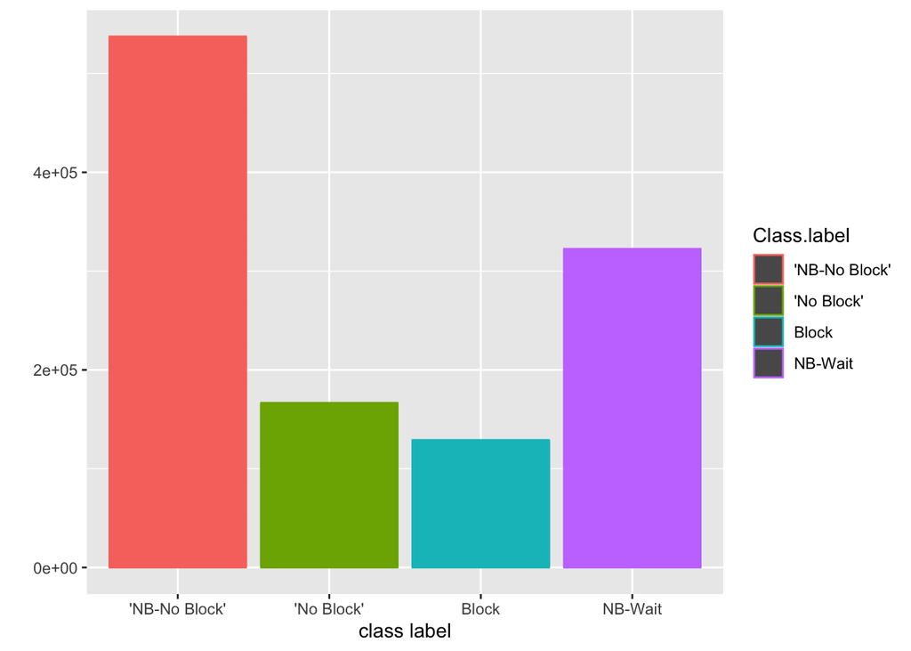

```r
data %>%
  ggplot(aes(x = Class.label, y = nrow(data), colour =Class.label))+
  geom_bar(stat = "identity")+labs(x = "class label",y = "") # plot to check the distribution of each class labels in OBS dataset.
```

```r
table(data$Class.label) # The number of instances for each class in the OBS network dataset
```

```
##
## 'NB-No Block'    'No Block'         Block       NB-Wait
##           500           155           120           300
```

Data distribution of all variables

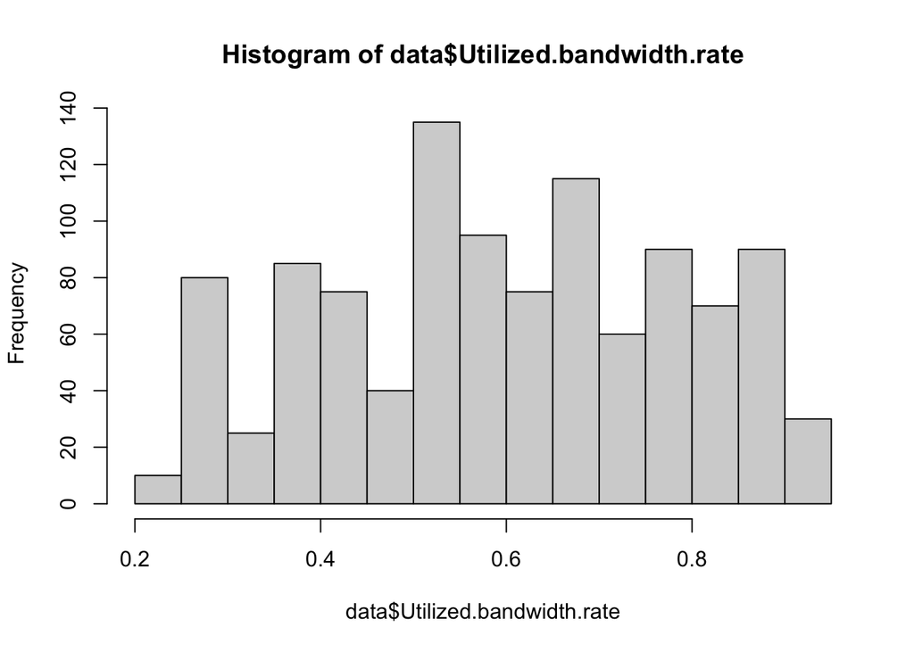

```r
hist(data$Utilized.bandwidth.rate)
```

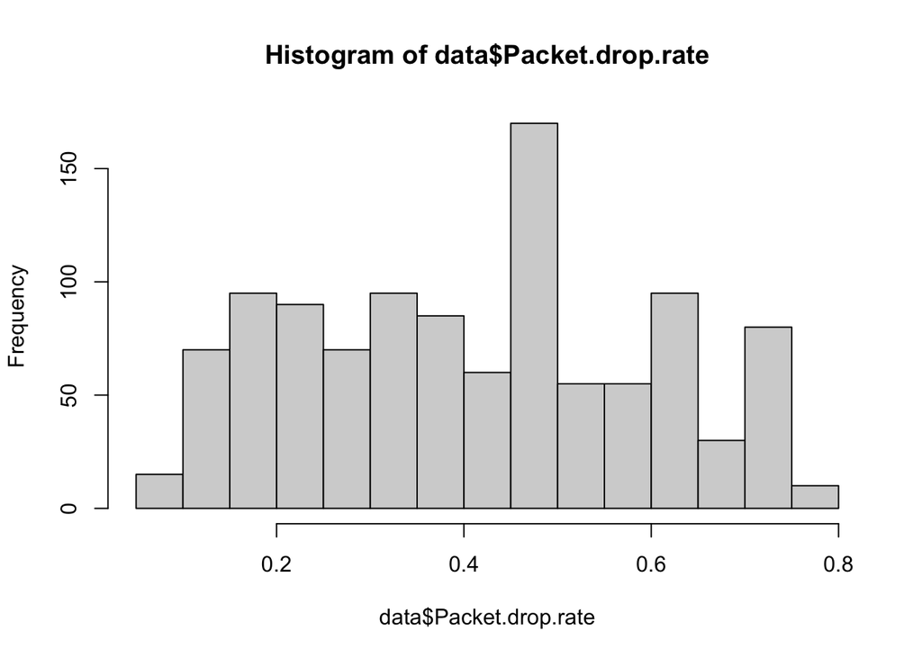

```r
hist(data$Packet.drop.rate)
```

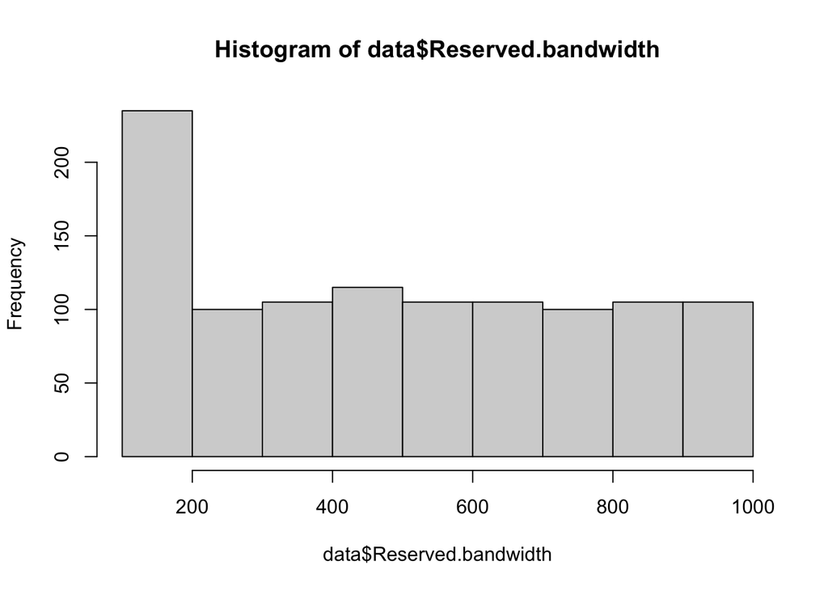

```r
hist(data$Reserved.bandwidth)
```

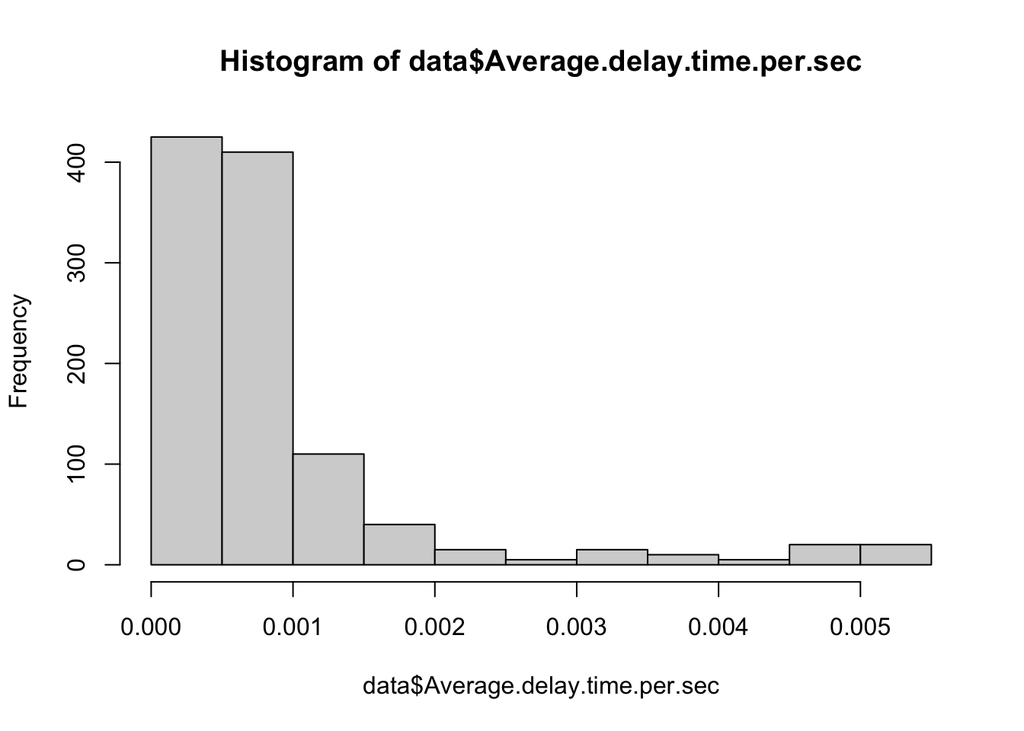

```r
hist(data$Average.delay.time.per.sec)
```

This variable is right skewed

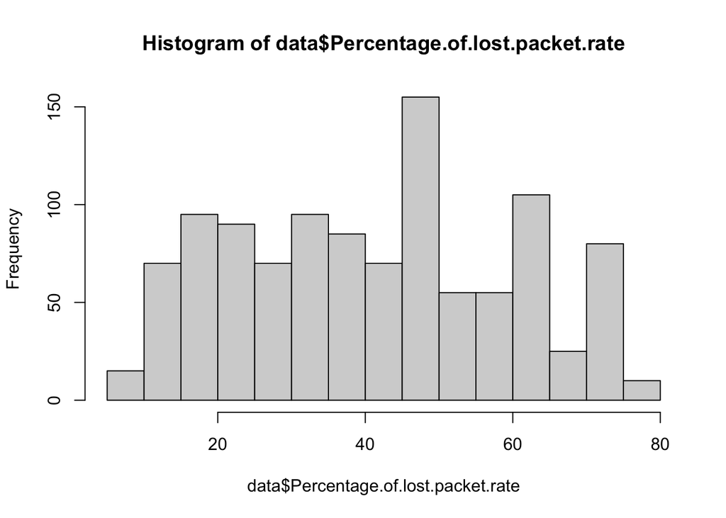

```r
hist(data$Percentage.of.lost.packet.rate)
```

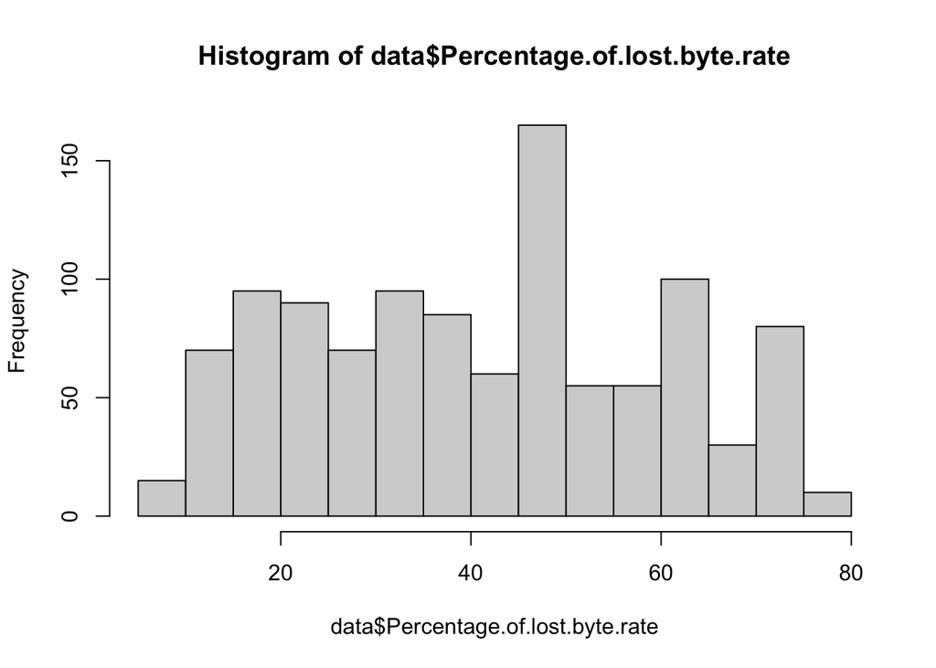

```r
hist(data$Percentage.of.lost.byte.rate)
```

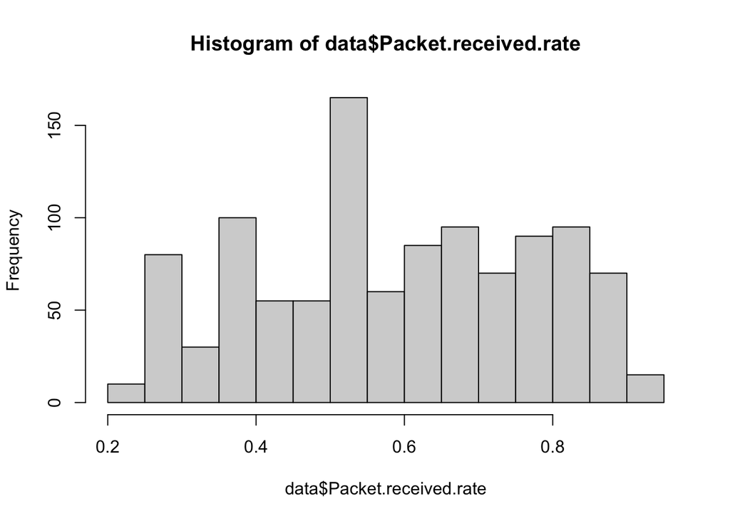

```r
hist(data$Packet.received.rate)
```

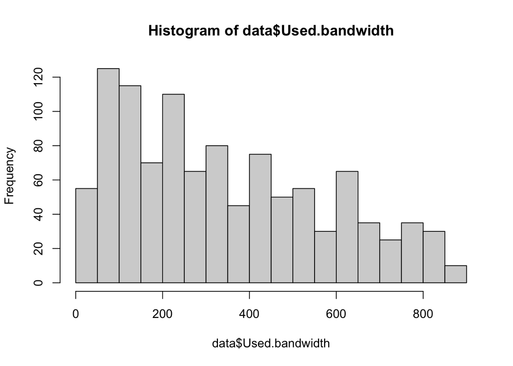

```r
hist(data$Used.bandwidth)
```

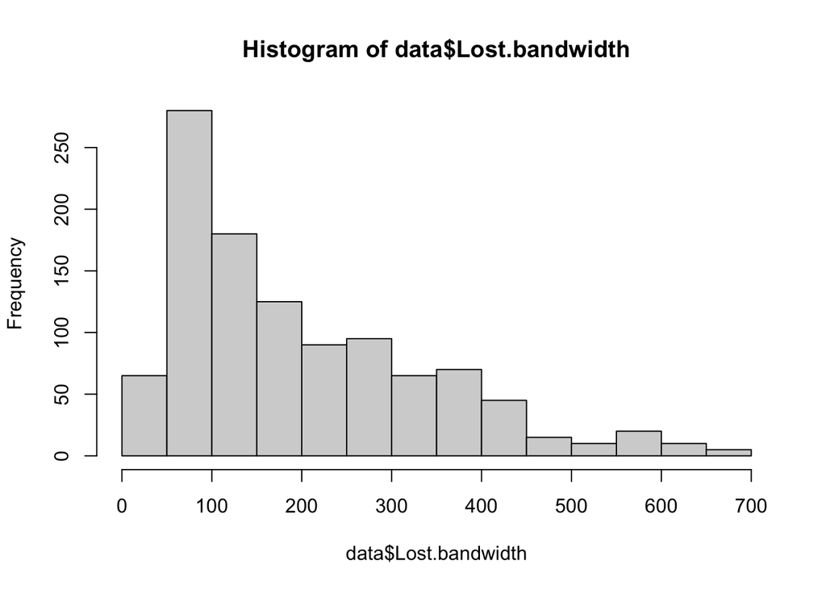

```r
hist(data$Lost.bandwidth)
```

This variable is right skewed

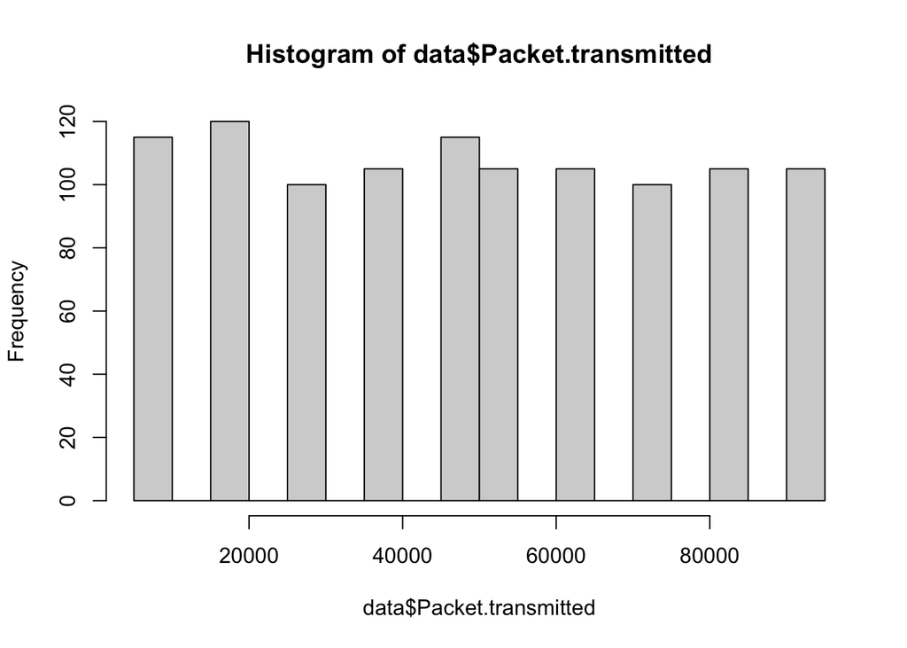

```r
hist(data$Packet.transmitted)
```

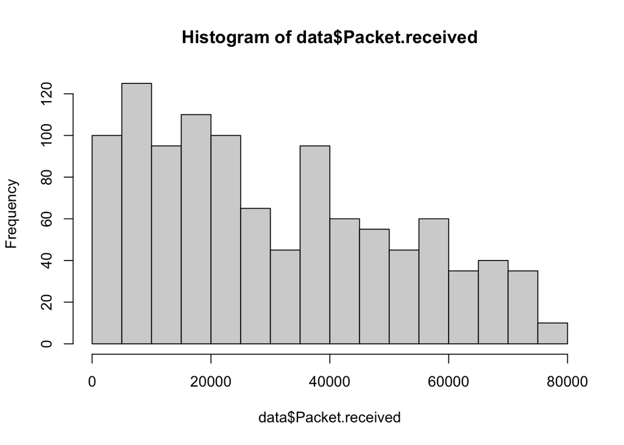

```r
hist(data$Packet.received)
```

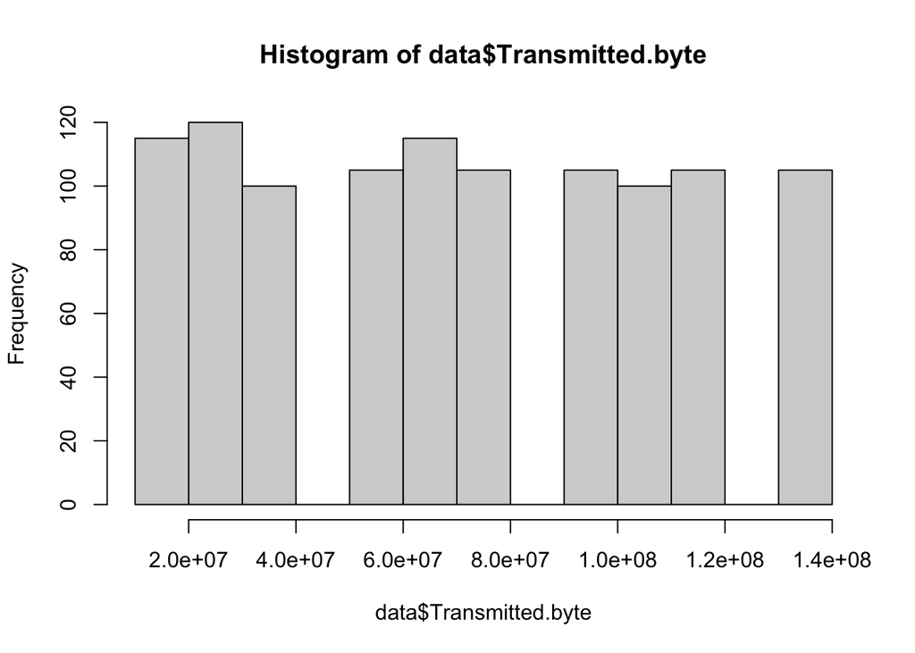

```r
hist(data$Transmitted.byte)
```

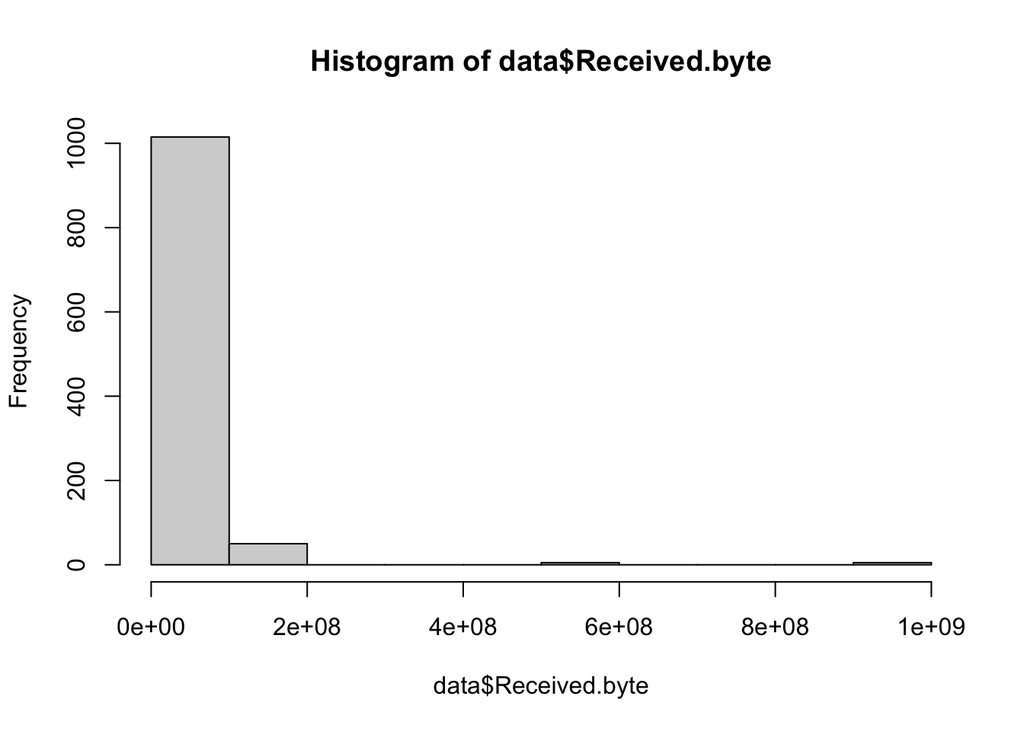

```r
hist(data$Received.byte)
```

Right skewed

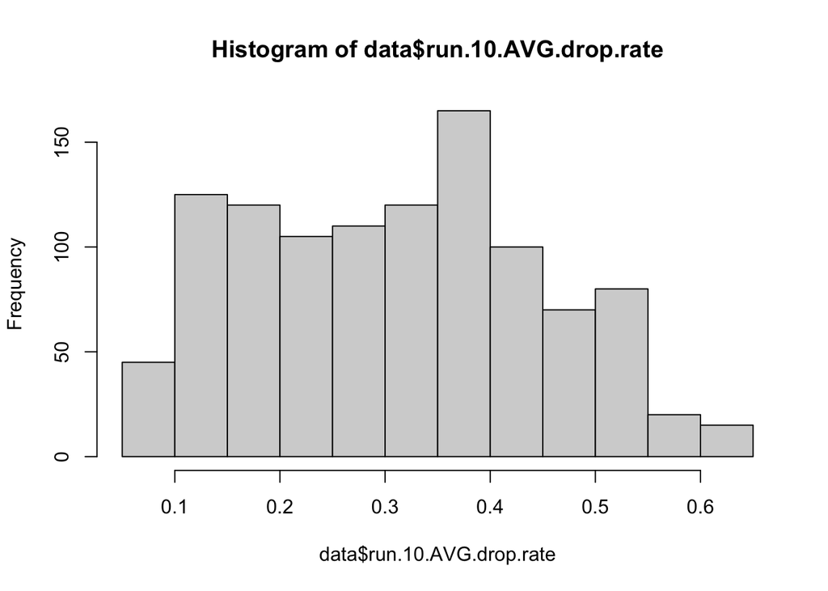

```r
hist(data$run.10.AVG.drop.rate)
```

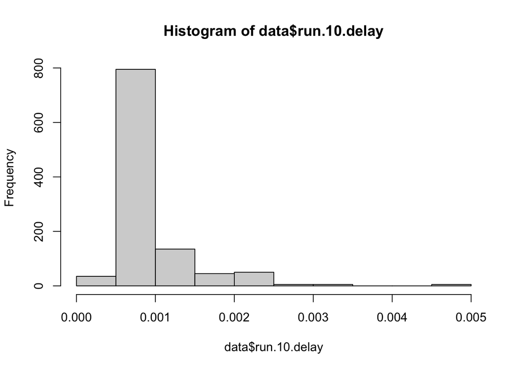

```r
hist(data$run.10.delay)
```

Right skewed

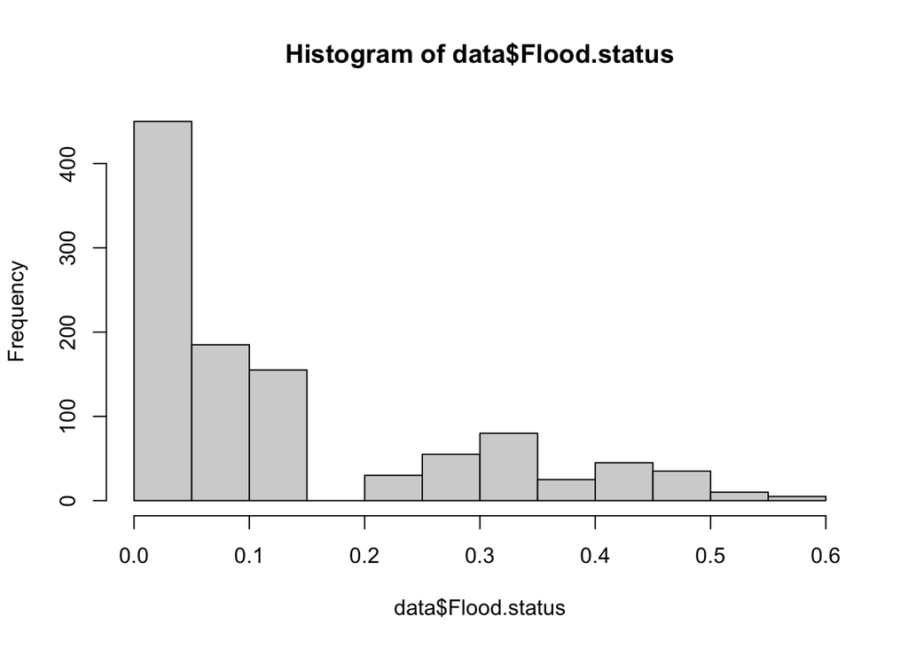

```r
hist(data$Flood.status)
```

Right skewed

# 5. Data Cleaning and Pre-processing

The attribute Packet size byte has been dropped because of its constant value of 1440 throughout all the accumulated samples in a dataset.

```r
data = data[,-11] # removing packet size byte

sum(is.na(data)) #To check any missing values in a dataset
```

```
## [1] 0
```

Now, the data is ready to carry out the further investigation.

# 6. Data Splitting

The data has been divided into training and testing sets, with 80% for the training and 20% for the testing set. The 20% testing data is held back and not exposed to the machine learning model until it is time to test the model.

```r
# using seed to get the same samples for the reproducibility
set.seed(123)
sample_split = sample.int(n = nrow(data), size = floor(.80*nrow(data)), replace = F) # data splitting into 80% and 20%
training_set = data[sample_split,] # training data with 80% samples
validation_set = data[-sample_split,] # test data with 20% samples
```

# 7. Model fitting

All the features are selected based on the forward feature selection method.

## LDA (Linear Discriminant Analysis)

Linear Discriminant Analysis (LDA) is one of the commonly used dimensionality reduction techniques in machine learning to solve more than two-class classification problems. It is also known as Normal Discriminant Analysis (NDA) or Discriminant Function Analysis (DFA).

```r
set.seed(1)
tcontrol <- trainControl(method = "cv", number = 10) # 10-fold cross validation
lda_model = train(Class.label~Utilized.bandwidth.rate+
                  Packet.drop.rate+
                  Reserved.bandwidth+
                  Average.delay.time.per.sec+
                  Percentage.of.lost.packet.rate +
                  Percentage.of.lost.byte.rate+
                  Used.bandwidth+
                  Packet.transmitted+
                  Packet.received+
                  run.10.AVG.drop.rate+
                  run.10.AVG.bandwidth.use+
                  log(run.10.delay)+# log transformation is used to normalize the variable as it is right skewed
                  Node +
                  Flood.status,
                data = training_set,
                method = "lda",
                trControl = tcontrol) # LDA model fitting using lda function on the training data (80% samples)
lda_pred = predict(lda_model, validation_set) # LDA model prediction on the test data (20% samples)
table(lda_pred, validation_set$Class.label) # confusion matrix
```

```
##
## lda_pred        'NB-No Block' 'No Block' Block NB-Wait
##   'NB-No Block'            72          1     0      27
##   'No Block'                6         25     0       0
##   Block                     1          0    32       2
##   NB-Wait                  17          0     0      32
```

The LDA Model accuracy score

```r
mean(lda_pred == validation_set$Class.label) # LDA Model accuracy score on the test data
```

```
## [1] 0.7488372
```

The LDA Model test error rate

```r
mean(lda_pred != validation_set$Class.label) # LDA model test error rate
```

```
## [1] 0.2511628
```

## QDA (Quadratic Discriminant Analysis)

Quadratic Discriminant Analysis (QDA) is a classification algorithm and it is used in machine learning and statistics problems. QDA is an extension of Linear Discriminant Analysis (LDA). Unlike LDA, QDA considers each class has its own variance or covariance matrix rather than to have a common one.

```r
set.seed(1)
qda_model = train(Class.label~Utilized.bandwidth.rate+
                  Packet.drop.rate+
                  Reserved.bandwidth+
                  sqrt(Average.delay.time.per.sec)+#sqrt transformation
                  Percentage.of.lost.packet.rate +
                  Percentage.of.lost.byte.rate+
                  Used.bandwidth+
                  Packet.transmitted+
                  Packet.received+
                  run.10.AVG.drop.rate+
                  run.10.AVG.bandwidth.use+
                  sqrt(run.10.delay)+ # sqrt transformation is used to normalize the variable as it is right skewed
                  Node,
                data = training_set,
                method = "qda",
                trControl = tcontrol) # QDA model fitting using lda function on the training data (80% samples)
qda_pred = predict(qda_model, validation_set) # QDA model prediction on the test data (20% samples)
table(qda_pred, validation_set$Class.label) # confusion matrix
```

```
##
## qda_pred        'NB-No Block' 'No Block' Block NB-Wait
##   'NB-No Block'            51          0     0       6
##   'No Block'               14         26     0       0
##   Block                    10          0    32      16
##   NB-Wait                  21          0     0      39
```

The QDA Model accuracy score

```r
mean(qda_pred == validation_set$Class.label)# QDA Model accuracy score on the test data
```

```
## [1] 0.6883721
```

The QDA Model test error rate

```r
mean(qda_pred != validation_set$Class.label) # QDA model test error rate
```

```
## [1] 0.3116279
```

## K Nearest Neighbor(KNN)

KNN which stand for K Nearest Neighbor is a Supervised Machine Learning algorithm that classifies a new data point into the target class, depending on the features of its neighboring data points.The knn () function needs to be used to train a model for which we need to install a package ‘class’. The knn() function identifies the k-nearest neighbors using Euclidean distance where k is a user-specified number.

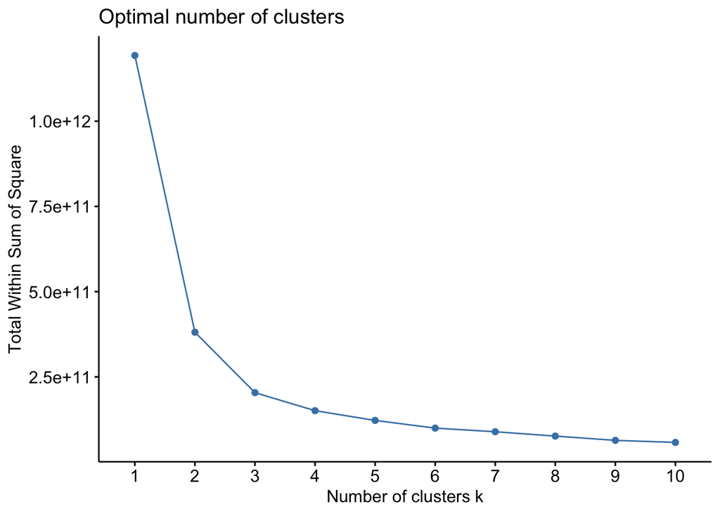

```r
best_selected_features = data %>%
  select(Node, Utilized.bandwidth.rate, Packet.drop.rate, Reserved.bandwidth, Average.delay.time.per.sec,
         Percentage.of.lost.packet.rate, Percentage.of.lost.byte.rate, Used.bandwidth, Packet.transmitted,
         Packet.received, run.10.AVG.drop.rate, run.10.AVG.bandwidth.use, run.10.delay, Flood.status) # selecting the best features which can give the better results for the model performance

fviz_nbclust(best_selected_features, kmeans, method = "wss") # elbow method plotting for the selected features
```

This shows an “elbow” or bends at k = 3 neighbours. The total within the sum of squares begins to level off at this point. This tells us that the optimal number of neighbors to use in the KNN algorithm is 3.

```r
set.seed(5)
knn_training = cbind(training_set$Node,# creating a matrix for knn_training data
           training_set$Utilized.bandwidth.rate,
           training_set$Packet.drop.rate,
           training_set$Reserved.bandwidth,
           sqrt(training_set$Average.delay.time.per.sec),#sqrt transformation
           training_set$Percentage.of.lost.packet.rate,
           training_set$Percentage.of.lost.byte.rate,
           training_set$Used.bandwidth,
           training_set$Packet.transmitted,
           training_set$Packet.received,
           training_set$run.10.AVG.drop.rate,
           training_set$run.10.AVG.bandwidth.use,
           log(training_set$run.10.delay),#log transformation
           sqrt(training_set$Flood.status)) #sqrt transformation

knn_testing = cbind(validation_set$Node, # creating a matrix for knn_testing data
           validation_set$Utilized.bandwidth.rate,
           validation_set$Packet.drop.rate,
           validation_set$Reserved.bandwidth,
           sqrt(validation_set$Average.delay.time.per.sec),#sqrt transformation
           validation_set$Percentage.of.lost.packet.rate,
           validation_set$Percentage.of.lost.byte.rate,
           validation_set$Used.bandwidth,
           validation_set$Packet.transmitted,
           validation_set$Packet.received,
           validation_set$run.10.AVG.drop.rate,
           validation_set$run.10.AVG.bandwidth.use,
           log(validation_set$run.10.delay), # log transformation
           sqrt(validation_set$Flood.status)) #sqrt transformation
classes = training_set$Class.label # Class label as the target variable


#k = 3
knn_model = knn(knn_training, knn_testing, classes, k = 3) # knn model fitting using knn function with 3 neighbor classifier
table(knn_model, validation_set$Class.label) # confusion matrix
```

```
##
## knn_model       'NB-No Block' 'No Block' Block NB-Wait
##   'NB-No Block'            93          0     0       3
##   'No Block'                0         26     0       0
##   Block                     0          0    32       3
##   NB-Wait                   3          0     0      55
```

The KNN Model accuracy score

```r
mean(knn_model == validation_set$Class.label)# KNN Model accuracy score on the test data
```

```
## [1] 0.9581395
```

The KNN Model test error rate

```r
mean(knn_model != validation_set$Class.label)# KNN model test error rate
```

```
## [1] 0.04186047
```

## Tree Classification

The main goal behind classification tree is to classify or predict an outcome based on a set of predictors.A Classification tree labels, records, and assigns variables to discrete classes. A Classification tree can also provide a measure of confidence that the classification is correct. A Classification tree is built through a process known as binary recursive partitioning.

```r
set.seed(6)
modfit.rpart <- rpart(Class.label~ Node +
                        Utilized.bandwidth.rate+
                        Packet.drop.rate+
                        Reserved.bandwidth+
                        Average.delay.time.per.sec+
                        Percentage.of.lost.packet.rate +
                        Percentage.of.lost.byte.rate+
                        Used.bandwidth+
                        Packet.transmitted+
                        Packet.received+
                        run.10.AVG.drop.rate+
                        run.10.AVG.bandwidth.use +
                        log(run.10.delay)+ #log transformation
                        Flood.status,
                      data = training_set, method="class", xval = 10)

tree_model <- predict(modfit.rpart, validation_set, type = "class") # Decision Tree model prediction on test set
table(tree_model, validation_set$Class.label) # confusion matrix
```

```
##
## tree_model      'NB-No Block' 'No Block' Block NB-Wait
##   'NB-No Block'            93          0     0      15
##   'No Block'                0         26     0       0
##   Block                     0          0    32       0
##   NB-Wait                   3          0     0      46
```

The Decision Tree Model accuracy score

```r
mean(tree_model == validation_set$Class.label)# Decision Tree Model accuracy score on the test data
```

```
## [1] 0.9162791
```

The Decision Tree Model test error rate

```r
mean(tree_model != validation_set$Class.label)# Decision Tree model test error rate
```

```
## [1] 0.08372093
```

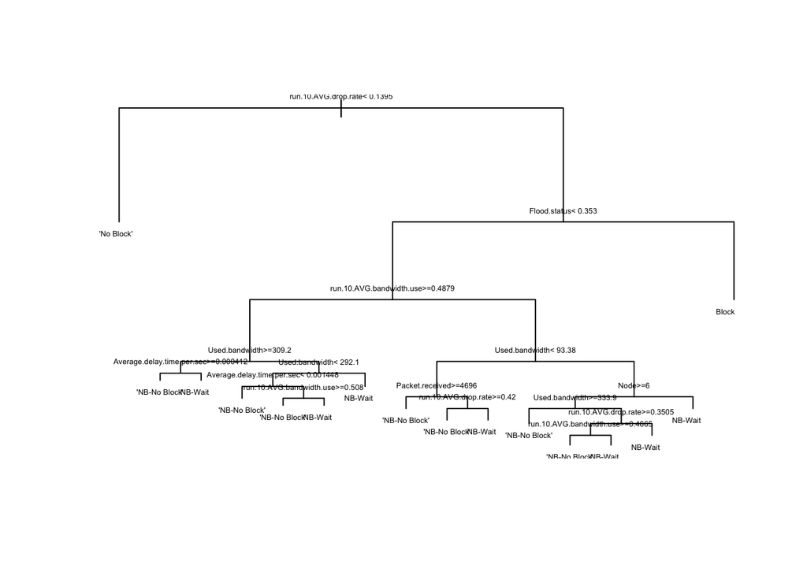

```r
plot(modfit.rpart) # Classification Tree plot
text(modfit.rpart, cex = 0.4)
```

## RandomForest

Random Forest is an ensemble of decision trees. It builds and combines multiple decision trees to get more accurate predictions. It’s a non-linear classification algorithm. Each decision tree model is used when employed on its own.Random forest adds additional randomness to the model, while growing the trees. Instead of searching for the most important feature while splitting a node, it searches for the best feature among a random subset of features. This results in a wide diversity that generally results in a better model.

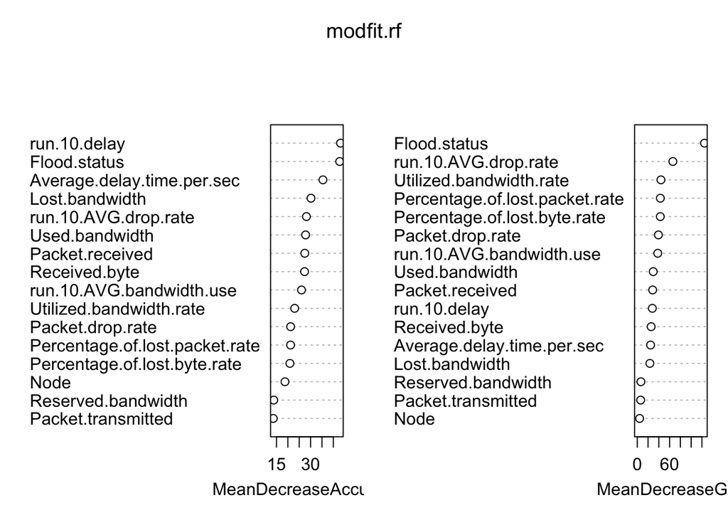

```r
set.seed(10)
training_set$Class.label = factor(training_set$Class.label) # converting into a factor for Randomforest Classification
modfit.rf <- randomForest(Class.label ~
                            Utilized.bandwidth.rate+
                            Packet.drop.rate+
                            Reserved.bandwidth+
                            Average.delay.time.per.sec+
                            Percentage.of.lost.packet.rate +
                            Percentage.of.lost.byte.rate+
                            Used.bandwidth+
                            Packet.transmitted+
                            Packet.received+
                            run.10.AVG.drop.rate+
                            run.10.AVG.bandwidth.use +
                            run.10.delay+
                            Node +
                            Flood.status+
                            Received.byte+
                            Lost.bandwidth,
                          data = training_set,
                          importance = T) # Random Forest model fitting with feature importance
varImpPlot(modfit.rf) # feature importance plot
```

Based on the feature importance plot two features namely, Flood status and run 10 delay were chosen to fit the lightweight Random Forest Model.

```r
modfit.rf <- train(Class.label ~ run.10.delay+ Flood.status,
                          data = training_set,
                          importance = T,
                   method = "rf",
                   trControl = tcontrol) # Random Forest Model with two features
random_forest_model <- predict(modfit.rf, validation_set) # model prediction on test set
table(random_forest_model, validation_set$Class.label) # confusion matrix
```

```
##
## random_forest_model 'NB-No Block' 'No Block' Block NB-Wait
##       'NB-No Block'            96          0     0       0
##       'No Block'                0         26     0       0
##       Block                     0          0    32       0
##       NB-Wait                   0          0     0      61
```

The Random Forest Model accuracy score

```r
mean(random_forest_model == validation_set$Class.label)
```

```
## [1] 1
```

# 8. Summary

```r
comparision_table = data.frame(Approch = c("LDA", "QDA", "KNN", "Decision Tree", "RandomForest"),
              No.of.features = c(14, 13, 14, 14, 2),
           Test.error.rate = c("25.11 %","31.16 %","4.18 %","8.37 %","0 %"),
           Acc.score = c("74.88 %","68.83 %","95.81 %","91.62 %","100 %"))
comparision_table
```

```
##         Approch No.of.features Test.error.rate Acc.score
## 1           LDA             14         25.11 %   74.88 %
## 2           QDA             13         31.16 %   68.83 %
## 3           KNN             14          4.18 %   95.81 %
## 4 Decision Tree             14          8.37 %   91.62 %
## 5  RandomForest              2             0 %     100 %
```

##### Table displays the different ML approaches and their comparisons via the number of features, accuracy, and test error rate.

##### It is clear from Table “RandomForest Model” has topped with an accuracy score of 100% with only two features directly connecting to the primary objective of devising a lightweight ML model to detect or classify the class labels in OBS networks. We can infer that decreasing the features to two and using the 10-fold cross validation and hold-out technique helped the suggested method to facilitate the overfitting problem and classify the OBS flooding attacks.